# Modelos (Descriptiva, BIOCLIM, MAXENT, GLM, BRT & RF)

Irene Extremera Serrano

11/2/2021

```r
library(sp) #Tabajar con objetos de tipo espacial
library(rgdal) #Es necesaria para la librería sdmpredictors
library(carData)
library(car)
library(nlme)
library(gstat)
library(sf)
library(spData)
library(spdep)
library(lattice)
library(survival)
library(Formula)
library(ggplot2) #Para gráficos de las predicciones
library(Hmisc)
library(raster) #Para poder trabajar con objetos tipo raster
library(leaflet)
library(GGally)
library(maptools)
library(corrplot)
library(rgeos)
library(maptools) #Cargar mapas
library(dismo) #Para poder trabajar con BIOCLIM y MAXENT
library(sdmpredictors) #Para descargarme las variables ambientales
library(PresenceAbsence)
library(rJava)
library(randomForest)
library(INLA) #Para trabajar con INLA
library(Matrix)
library(parallel)
library(foreach)
library(dotCall64)
library(grid)
library(spam)
library(fields)
library(randomForest) #Para realizar Random Fores
library(gbm) #Para realizar vosted regression tree
```

CARGAR LAS BASES DE DATOS

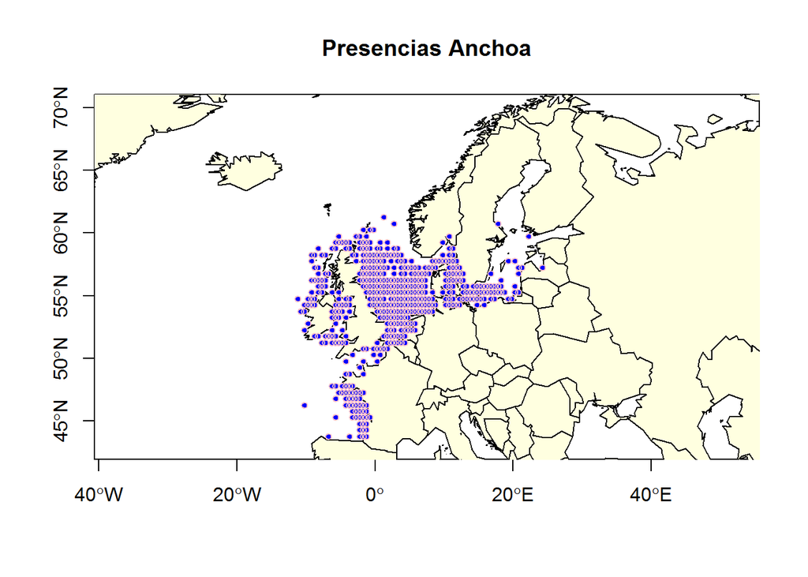

```r
# Asignamos un directorio de trabajo

setwd("C:/Users/Irene/Source/Repositorios/TFM-Irene-Extremera/Rmd")

# MAPA DEL MUNDO

data(wrld_simpl)

# PRESENCIA DE ANCHOAS
# Descargué la base de datos de AQUAMAPS y eliminé las ubicaciones que no perteneciesen a Atlántico norte mediante la función: identify() y posteriormente quitándolas de la base de datos.
# Otra cosa a realizar fue la identificación de duplicados mediante las siguientes líneas de código:

# dups2 <- duplicated(data[, c("Lon","Lat")]) #Miro si hay duplicados
# sum(dups2) #Veo cuántos duplicados
# data <- data[!dups2, ] #Verifico si son diferentes antes de eliminarlos.

# Si existiesen duplicados habría que eliminarlos de la base de datos, en este caso no hubo ninguno.
# Después de todo este procedimiento, guardé esa base de datos con presencias únicamente de Atlántico norte.

data <- read.csv('C:/Users/Irene/Source/Repositorios/TFM-Irene-Extremera/Datos/Anchoas_Aqua_atln.csv',TRUE,",")


data <- data[,-1] #Le quito al primera que es una columna de índices
colnames(data) <- c('Lon','Lat') #Le doy nombre a las columnas

#Realizo un plot para cerciorarme que todo está en orden

plot(wrld_simpl, xlim= c(-20,35),ylim=c(43,70), axes=TRUE,col="light yellow", main='Presencias Anchoa')
points(data$Lon, data$Lat, col="blue", pch=20, cex=0.75)
points(data$Lon, data$Lat, col="pink", cex=0.75)
```

```r
#PREDICTORES de MASPEC y BIO-ORACLE
# A la hora de seleccionar variables nos hemos guiado por la biología de la especie. Por lo que decidimos trabajar con: batimetría, salinidad, oxígeno disuelto, temperatura media superficial, clorofila media y producción primaria media.

# Para descargarlas utilicé las siguientes líneas de código:

# Llamo primero a los rasters por separado. Como se puede observar, batimetría pertenece a MASPEC y el resto a Bio-Oracle.

# bathy<- load_layers(c("MS_bathy_5m"))
# chlomean<- load_layers(c("BO2_chlomean_ss"))
# ppmean<- load_layers(c("BO2_ppmean_ss"))
# tempmean <- load_layers(c("BO2_tempmean_ss"))
# odismean<- load_layers(c("BO2_dissoxmean_ss"))
# salinity <- load_layers(c("BO2_salinitymean_ss"))

# La longitud de bathy y chlomean es diferente por lo que había que igualarlas al resto con la función resample.

# bathy<-resample(bathy,salinity)
# chlomean<-resample(chlomean,salinity)

# ¿CÓMO ME DI CUENTA DE ESTO?

# Corté los rasters para luego guardarlos y que así me ocupasen menos

# ext <-extent(-20,35,43,70) #Para Atlántico Norte
# bathy<-crop(bathy,ext)
# chlomean<-crop(chlomean,ext)
# ppmean<-crop(ppmean,ext)
# tempmean<-crop(tempmean,ext)
# odismean<-crop(odismean,ext)
# salinity<-crop(salinity,ext)

# writeRaster(bathy, filename="bathy_atln.tif", format="GTiff", overwrite=TRUE)
# writeRaster(chlomean, filename="chlomean_atln.tif", format="GTiff", overwrite=TRUE)
# writeRaster(ppmean, filename="ppmean_atln.tif", format="GTiff", overwrite=TRUE)
# writeRaster(odismean, filename="odismean_atln.tif", format="GTiff", overwrite=TRUE)
# writeRaster(salinity, filename="salinity_atln.tif", format="GTiff", overwrite=TRUE)
# writeRaster(tempmean, filename="tempmean_atln.tif", format="GTiff", overwrite=TRUE)
```

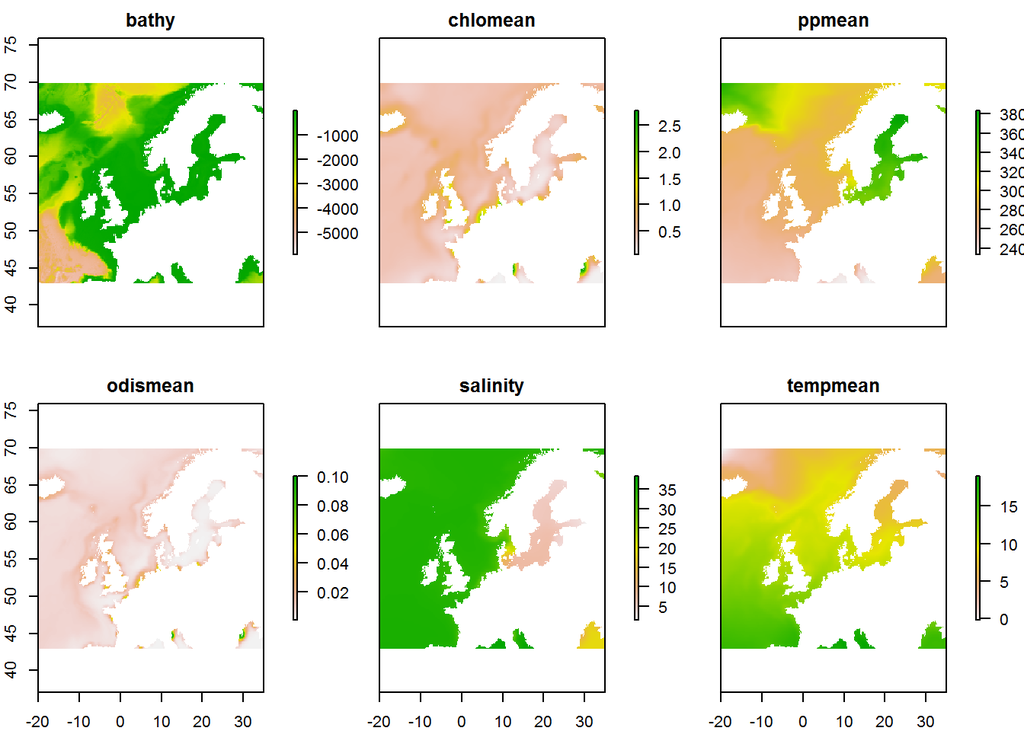

```r
# Ahora simplemente pueden cargarse sin necesidad de tener que descargarlos.
# Para que salga bien es muy importante que los predictores estén en una misma carpeta.

files<-(list.files("C:/Users/Irene/Source/Repositorios/TFM-Irene-Extremera/Predictores/atl", full.names=T, pattern=".tif"))#change directory
predictors <- stack(files)
names(predictors) <- c("bathy","chlomean","ppmean","odismean","salinity","tempmean")
plot(predictors) #Los pinto
```

```r
# Miro a ver si hay NAs
# values(predictors) #Los hay y probablemente sean de la parte de la tierra

# Escalo los valores para que al hacer el análisis todas las variables tengan la misma escala

predictors2 <- scale(predictors)
round(apply(values(predictors2), 2, summary), 4) #Me cercioro que estén con media en cero
```

```
                bathy    chlomean      ppmean    odismean    salinity    tempmean
  Min.        -2.9599     -1.9189     -1.7610     -1.2042     -3.5490     -3.1053
  1st Qu.     -0.6782     -0.4285     -0.6983     -0.4270      0.2883     -0.5929
  Median       0.4844     -0.2119     -0.2759     -0.1197      0.3707     -0.0332
  Mean         0.0000      0.0000      0.0000      0.0000      0.0000      0.0000
  3rd Qu.      0.8248      0.3208      0.3997      0.1735      0.4024      0.6696
  Max.         0.8753     11.0021      3.0051     16.4101      0.7560      2.5428
  NA's    100238.0000 100229.0000 102281.0000 102281.0000 102281.0000 102281.0000
```

```r
# Para comprobar que todo está igual para que no me dé problemas habría que usar las siguientes funciones:
# crs() #miramos el systema de referencia de las coordenadas #+proj=longlat +datum=WGS84 +no_defs
# res() #ver resolucion del raster #0.08333333 0.08333333
# yres() ; xres() #ver resolucion del raster
```

El sistema de referencia es el de coordenadas cartográficas y la resolución es de 0.0833º.

##### — Presencias, Pseudoausencias & Otras cosas —

```r
# Una vez que se dispone de las presencias y de las variables predictoras el objetivo siguiuente es:
# 1- La creación de pseudoausencias
# 2- La adjudicación a esos puntos concretos de presencia y de pseudoausencia sus valores ambientales
# 3- El almacenamiento de esta información en una base de datos.

# PRESENCIAS:
# Extraigo las coordenadas de presencias y les doy nombre
# coords_pres <- cbind(data$Lon, data$Lat)
# colnames(coords_pres)<-c("x","y")

# La función extract permite extraer los valores de la variable ambiental de las coordenadas donde están las presencias
# presvals <- extract(predictors2, coords_pres)

# Me cercioro de que todo está correcto
# head(presvals)
```

```r
# PSEUDOAUSENCIAS
# Pongo una semilla para que me aparezcan los puntos en el mismo sitio
# Genero 1000 pseudoausencias en la zona que me interesa

set.seed(141592)
backgr <- randomPoints(predictors2, 1000)

# Lo transformo en data.frame para poder trabajar con ellas
# backgr <-as.data.frame(backgr)
# head(backgr) # Miro que todo está bien.

# Extraigo valores de las variables ambientales de las pseudoausencias
# absvals <- extract(predictors2, backgr)

# Me cercioro de que todo está bien
# head(absvals)
```

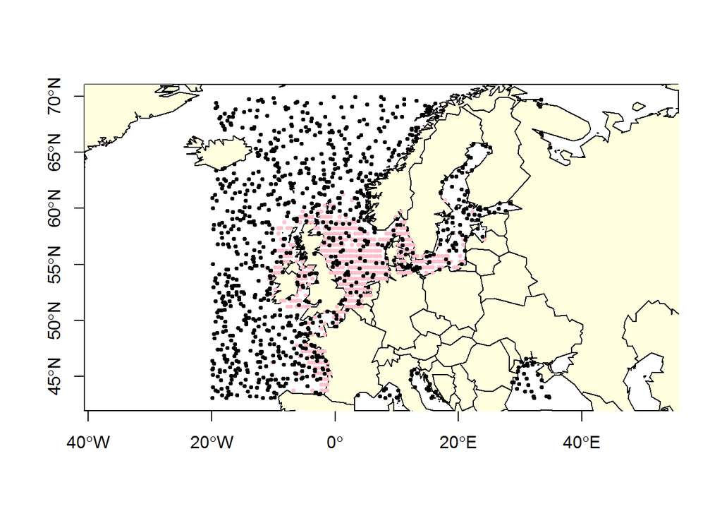

```r
# Pinto las pseudoausencias con el fin de ver que efectivamente se han creado bien

plot(wrld_simpl, xlim= c(-20,35),ylim=c(43,70), axes=TRUE,col="light yellow")
points(data$Lon, data$Lat, col="pink", pch=20, cex=0.75)
points(backgr, col="black", pch=20, cex=0.75)
```

```r
# JUNTAR TODO EN UNA BASE DE DATOS
# Genero un único vector de coordenadas de presencias y pseudoausencias
# coords<-as.data.frame(rbind(coords,backgr))

# Genero un vector con tantas presencias (1) y ausencias (0) haya
# pb <- c(rep(1, nrow(presvals)), rep(0, nrow(absvals)))

# Junto los datos de las variables ambientales de presencia y pseudoausencia con los 0 y 1.
# sdmdata <- data.frame(cbind(pb, rbind(presvals, absvals), coords))
# head(sdmdata)

#Hay que mirar si hay NAs: si son pocos se quitan, pero si son muchos habría que valorar el hacer una imputación de la media de los datos que están cercanos.
# summary(sdmdata)
# to.remove <- which(!complete.cases(sdmdata))
# sdmdata <- sdmdata[-to.remove,]

# Se vuelve a hacer el summary para cerciorarse de que ya no hay NAs
# summary(sdmdata)

# Se guarda la base de datos
# write.csv(sdmdata,"Datos/sdmdata.csv")

# Se carga la base de datos
sdmdata <- read.csv("C:/Users/Irene/Source/Repositorios/TFM-Irene-Extremera/Datos/sdmdata.csv")
```

—– Descriptiva —–

Una vez obtenidae la base datos a punto comienza la descriptiva.

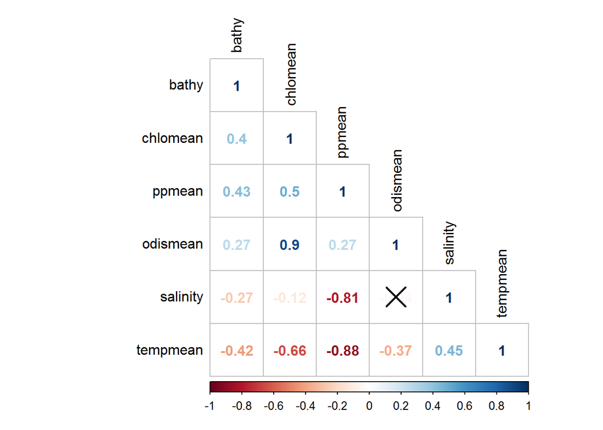

```r
# Miro la correlación entre variables para identificar qué variables o no incluir.
# La correlación se empieza a plantear el no introducir la variable partir de 0.7.
# Hacer modelos con correlación y sin ella para ver cómo ajustan y ver cómo se explica (opcional)

matrix<-rcorr(as.matrix(sdmdata[,c(3:8)]), type = "pearson")

# ... : further arguments to pass to the native R cor.test function
cor.mtest <- function(mat, ...) {
  mat <- as.matrix(mat)
  n <- ncol(mat)
  p.mat<- matrix(NA, n, n)
  diag(p.mat) <- 0
  for (i in 1:(n - 1)) {
    for (j in (i + 1):n) {
      tmp <- cor.test(mat[, i], mat[, j], ...)
      p.mat[i, j] <- p.mat[j, i] <- tmp$p.value
    }
  }
  colnames(p.mat) <- rownames(p.mat) <- colnames(mat)
  p.mat
}

corrplot(matrix$r, type="lower", tl.col = "black",method="number",
         p.mat = matrix$P, sig.level = 0.05)
```

Se puede observar que las correlaciones entre algunas de las distintas variables son bastante altas: - Chlomean y odismean con un 0.89, bastante alta y positiva. - ppmean tiene una correlación negativa alta con salinidad -0.81 y tempmean -0.88.

A si a primera vista diría que las variables mas indicadas para entrar en el modelo serían: bathy, odismean, salinity y tempmean.

A continuación realizo un ggpairs para ver qué tipo de relación hay entre las covariables escaladas y sin escalar.

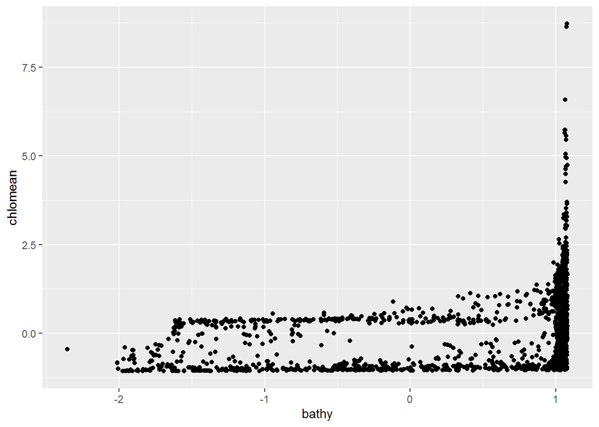

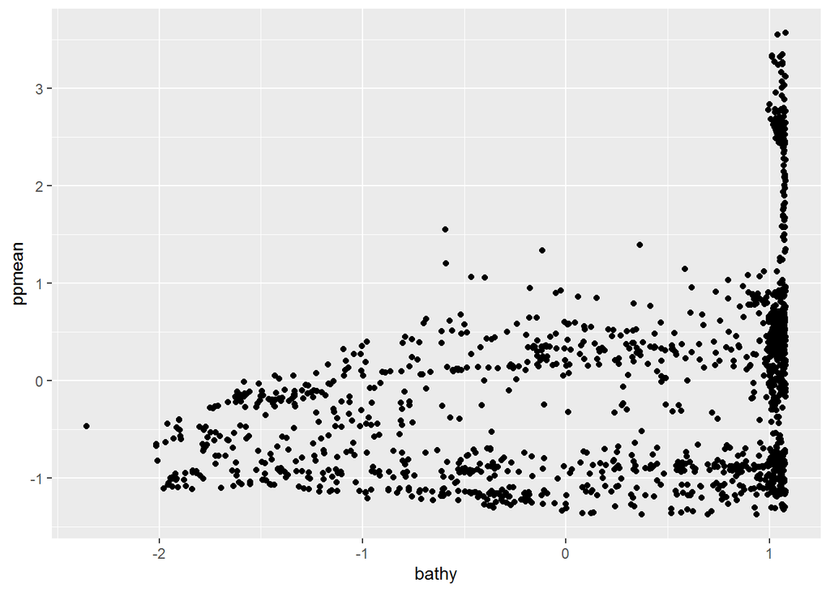

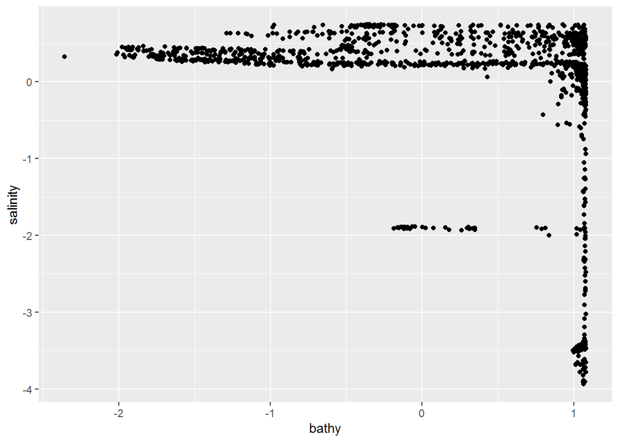

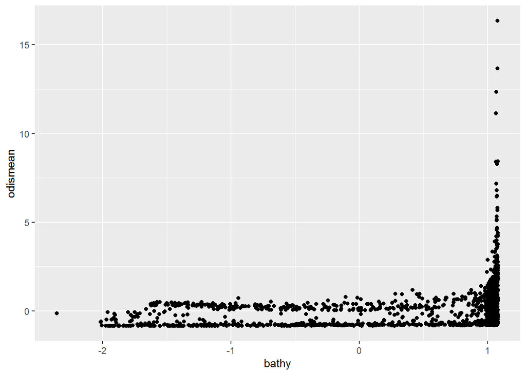

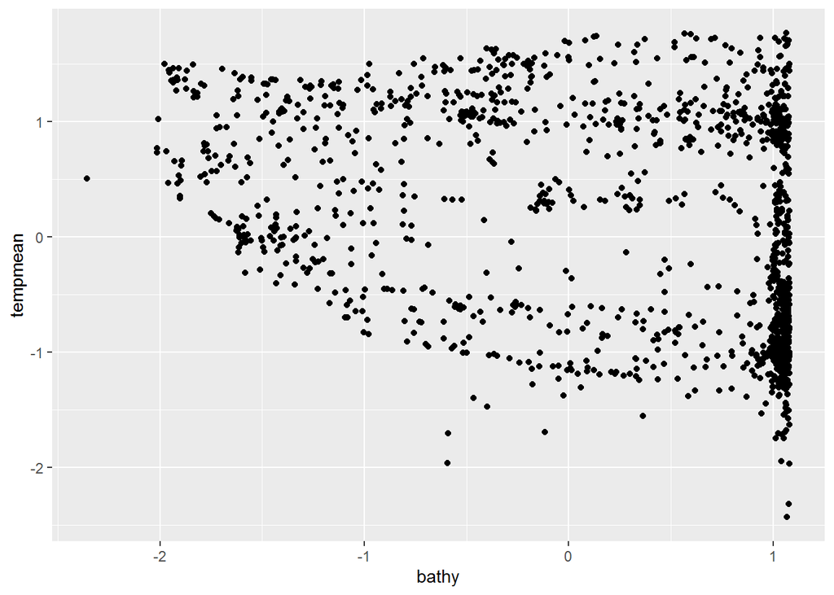

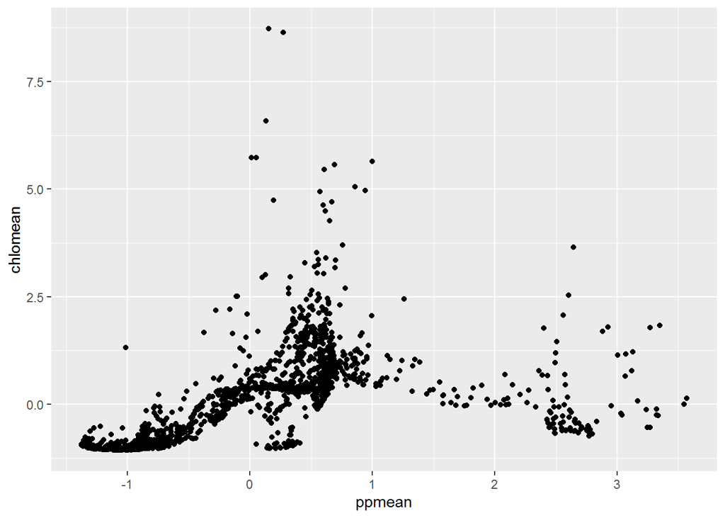

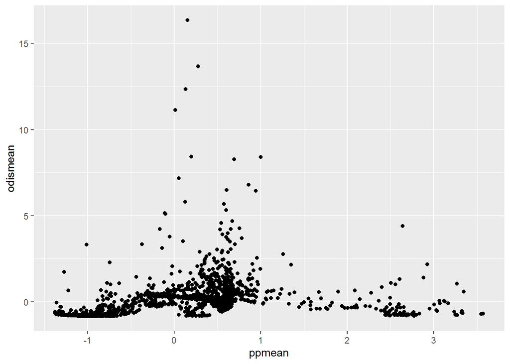

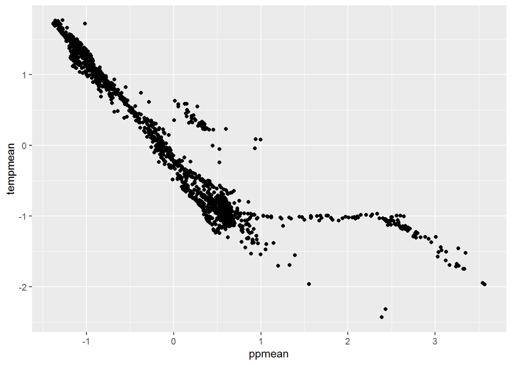

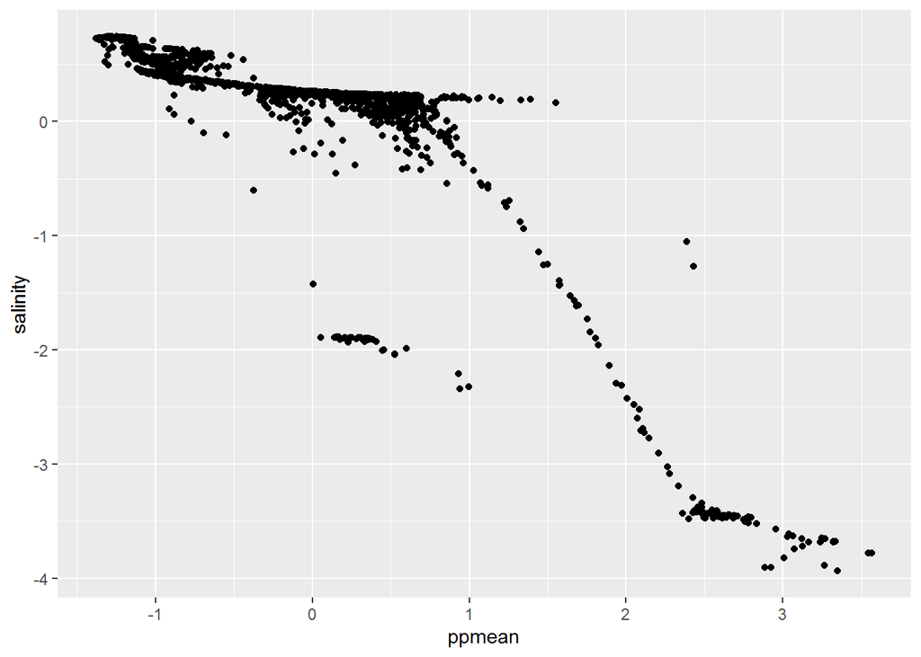

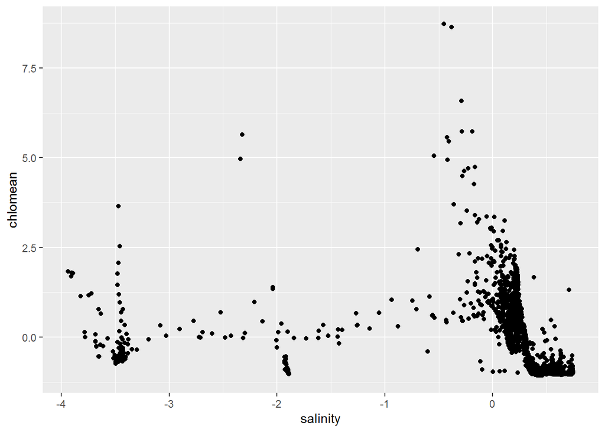

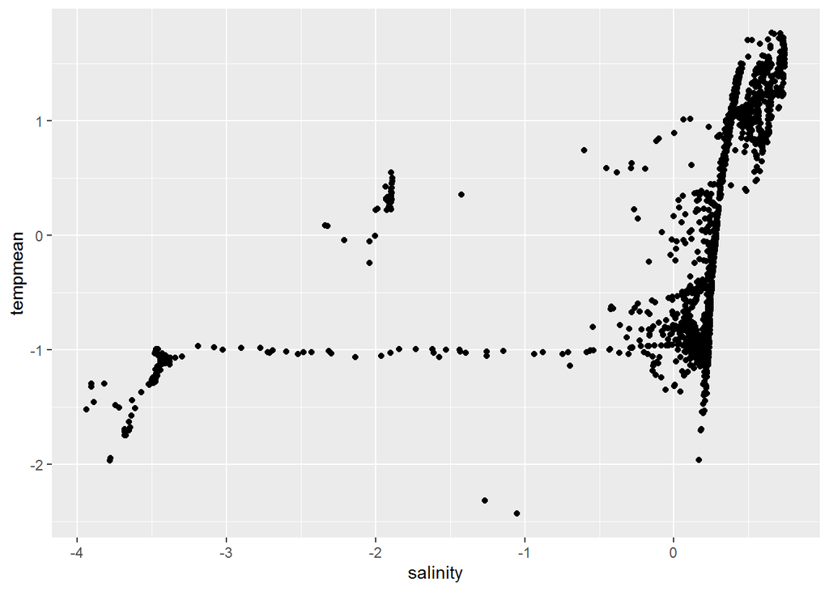

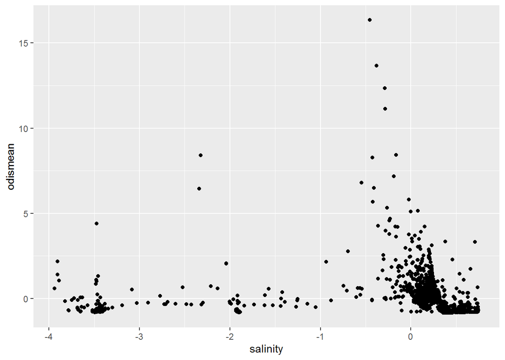

[3 more figures not shown]

Se observa que la forma que tienen de relacionarse las variables entre ellas es bastante extraña en algunos casos. Por ello se valora a continuación realizar estos mismos gráficos con las variables ambientales sin escalar.

```r
# SIN ESCALAR
# Para ello hay que preparar una base de datos como la de sdmdata pero con los predictores no escalados

# PRESENCIAS

coords_pres <- cbind(data$Lon, data$Lat)
colnames(coords_pres)<-c("x","y")
presvals_nos <- extract(predictors, coords_pres)

# AUSENCIAS

absvals_nos <- extract(predictors, backgr)

# COORDENADAS

coords_nos<-as.data.frame(rbind(coords_pres,backgr))

# 1 & 0

pb <- c(rep(1, nrow(presvals_nos)), rep(0, nrow(absvals_nos)))

# BASE DE DATOS

sdmdata_nos <- data.frame(cbind(pb, rbind(presvals_nos, absvals_nos), coords_nos))

# NAs

to.remove <- which(!complete.cases(sdmdata_nos))
sdmdata_nos <- sdmdata_nos[-to.remove,]
```